# Hypothesis testing

James Muguira

March 25, 2016

The goal of Hypothesis testing is: “Given a sample and an apparent effect, what is the probability of seeing such an effect by chance (Downey, 2016, p. 109)?” To answer that question you would work through the following process:

1. Choose a test statistic (also called Alpha). Many situations start with a statistic of 95%.
2. Define a NULL hypothesis. The NULL hypothesis assumes there is no effect. For example the means are equal (no difference)
3. Compute a p-value. The p-value is the probability of seeing the effect if the NULL hypothesis is true.
4. Interpret the results. To continue the example, the NULL hypothesis says the means are equal, so a low p-value (i.e. p-value < alpha) would indicate that the effect is NOT likely to have occurred by chance.

Hypothesis testing is similar to proving a mathematical statement by contradiction. The proof by contradiction works like this: Assume for the moment that the effect you are testing is not real (this corresponds to the Null Hypothesis), compute the probability (the p-value) and if that is low then the NULL hypothesis is not likely to be true.

Hypothesis testing can used to investigate several different types of interaction:

- Testing to see if a sample mean could be contained in a population
- Testing to see if the mean/median of two equal length vectors are equal
- Testing to see if proportions are equal

Let’s do an example of each of the above test types.

*Testing a Population Parameter*

To solve this in R use prop.test…

```r
f = prop.test(41, 100, p=0.5)
f
```

```
##
##  1-sample proportions test with continuity correction
##
## data:  41 out of 100, null probability 0.5
## X-squared = 2.89, df = 1, p-value = 0.08913
## alternative hypothesis: true p is not equal to 0.5
## 95 percent confidence interval:
##  0.3140323 0.5129652
## sample estimates:
##    p
## 0.41
```

First, the null hypothesis:

- Half the students like the flavors
- Half the students don’t like the flavors

Second, notice this is a two-sided test. 41 students said yes and 59 said no. The p-value tells us how likely we are to see this data or worse. In our case, 8% of the time we would see data like this. We would have to accept the null hypothesis that 50% of the students sampled liked the flavor selection. Notice, what happens if the numbers changed a little. Let’s run 2 more tests:

```r
f = prop.test(38, 100, p=.5)
f
```

```
##
##  1-sample proportions test with continuity correction
##
## data:  38 out of 100, null probability 0.5
## X-squared = 5.29, df = 1, p-value = 0.02145
## alternative hypothesis: true p is not equal to 0.5
## 95 percent confidence interval:
##  0.2863947 0.4829411
## sample estimates:
##    p
## 0.38
```

```r
f = prop.test(45, 100, p=.5)
f
```

```
##
##  1-sample proportions test with continuity correction
##
## data:  45 out of 100, null probability 0.5
## X-squared = 0.81, df = 1, p-value = 0.3681
## alternative hypothesis: true p is not equal to 0.5
## 95 percent confidence interval:
##  0.3514281 0.5524574
## sample estimates:
##    p
## 0.45
```

When only 38 students said yes, we could expect the model to be right only 2% of the time. Remember that we are sampling from a large population (lots and lots of surveys). In the case of 45 students saying yes, we could expect to see that case 37% of the time.

*Testing a Mean/median*

Suppose your dubious friend Fred is selling jars of jellybeans. He claims there are 50 Jellybeans in each jar. You ask 10 people who bought the jars to count their jellybeans and find that the mean was 40 with a standard deviation of 1.5. Should you believe Fred’s claim?

To test this use the following:

```r
xbar = 40
s = 1.5
n = 10
fred = 50
t = (xbar - fred) / (s / sqrt(n))
t
```

```
## [1] -21.08185
```

```r
pt(t, df=n-1)
```

```
## [1] 2.851276e-09
```

The p-value (2.85 x 10^-9) is really small. Fred’s claim is suspicious.

But what if, after sampling 10 jars, you found that the mean was 47 and the standard deviation was 2.1? Can you trust Fred?

```r
xbar <- 47
s <- 2.1
n <- 10
fred <- 50
t = (xbar - fred) / (s / sqrt(n))
pt(t, df=n-1)
```

```
## [1] 0.0007259553
```

The p-value still indicates that Fred might might be short in his counts. One more example, what if your sample mean was 55 with a standard deviation of 2.1? The computed p-value is over 99%! What does this say? In this case, Fred is cheating himself!

*Tests for the Median*

Suppose a cell phone manufacturer claims their new ZZ3 cell phone has a battery life of 8 hours on a single charge! You ask 8 friends that have purchased the phone to report their battery life for a test.

```r
hr = c(8, 7, 5.1, 4.2, 9, 10, 3, 6)
# what is the mean of this sample?
mean(hr)
```

```
## [1] 6.5375
```

```r
# the simple thing would be to do a t.test, but can you?
stem(hr)
```

```
##
##   The decimal point is at the |
##
##    2 | 0
##    4 | 21
##    6 | 00
##    8 | 00
##   10 | 0
```

```r
# If would appear that the data is clustered around 4, so a t.test is ok.
t.test(hr, mu=8, alternative='less')
```

```
##
##  One Sample t-test
##
## data:  hr
## t = -1.7147, df = 7, p-value = 0.06506
## alternative hypothesis: true mean is less than 8
## 95 percent confidence interval:
##     -Inf 8.15343
## sample estimates:
## mean of x
##    6.5375
```

The results indicate that 6.5% of the time you might get a sample with a median of 8 hrs. The manufacturer is on the border here; the phone will get close to 8 hours of battery life. Rerunning the test with a mu of 7 indicates that the battery life might be closer to 7 than 8 hours.

*Tests of Proportion*

Suppose your friend Dan says that he has invented a new type of paper that makes paper airplanes fly further. You decide to test Dan’s claims. Your Null Hypothesis is that there is no difference in paper types. You make 10 test flights in the gym:

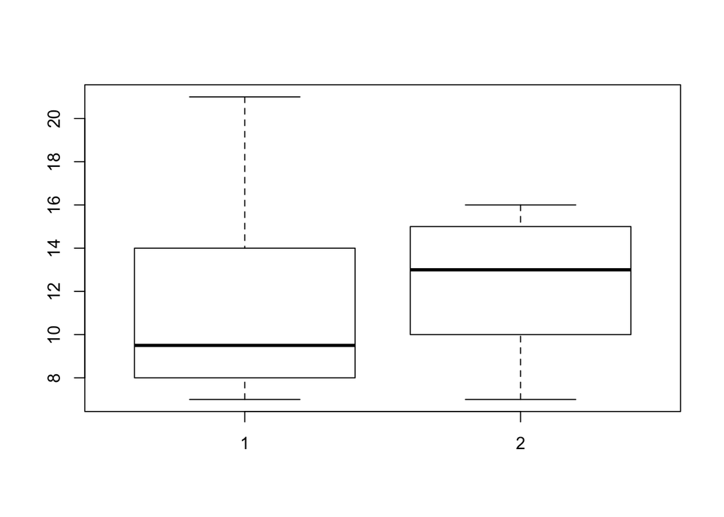

```r
newPaper = c(15, 10, 13, 7, 9, 8, 21, 9, 14, 8)
oldPaper = c(15, 14, 12, 8, 14, 7, 16, 10, 15, 12)
# First, let's check that the data are normal and relatively equal variance
boxplot(newPaper, oldPaper)
```

```r
# let's try a t.test
t.test(newPaper, oldPaper, alternative = 'less', var.equal = TRUE)
```

```
##
##  Two Sample t-test
##
## data:  newPaper and oldPaper
## t = -0.53311, df = 18, p-value = 0.3002
## alternative hypothesis: true difference in means is less than 0
## 95 percent confidence interval:
##      -Inf 2.027436
## sample estimates:
## mean of x mean of y
##      11.4      12.3
```

The p-value indicates that there is no difference in paper type (p-value = 0.30).

*Conclusion*

There is more to Hypothesis testing. I encourage you to read and try the examples in the book “SimpleR”. The concept of a NULL and Alternate hypothesis is fundamental to many statistical tests. As you will see in the next lecture, the type of data you are investigating determines the type of test you will apply.

Stay Tuned!

Reference: Downey, A. (2016, March 25). Think Stats: Probability and Statistics for Programmers. Retrieved March 25, 2016, from http://greenteapress.com/thinkstats2/